# Reproducible Research: Peer Assessment 1

Loading *dplyr* & *ggplot* libraries

```r
   library(dplyr)
```

```r
   library(ggplot2)
```

## I. Loading and preprocessing the data

1. Retrive the activity monitoring data sample from [Activity monitoring data](https://d396qusza40orc.cloudfront.net/repdata%2Fdata%2Factivity.zip) ,then load it into a dataframe called **dataRaw** using **read.csv**.

```r
     if (!file.exists("./activity.csv")){

           if(!file.exists("./activity.zip")){
               download.file("https://d396qusza40orc.cloudfront.net/repdata%2Fdata%2Factivity.zip",
                             "./activity.zip")
           }
           unzip("./activity.zip")
      }

      dataRaw <- read.csv("./activity.csv")
      inpRows <- nrow(dataRaw)
      naRows  <- nrow(dataRaw[is.na(dataRaw$steps),])
      str(dataRaw)
```

```
## 'data.frame':    17568 obs. of  3 variables:
##  $ steps   : int  NA NA NA NA NA NA NA NA NA NA ...
##  $ date    : Factor w/ 61 levels "2012-10-01","2012-10-02",..: 1 1 1 1 1 1 1 1 1 1 ...
##  $ interval: int  0 5 10 15 20 25 30 35 40 45 ...
```

2. Here is information/metadata about our activity dataset variables.
- **steps:** Number of steps taking in a 5-minute interval (there are **2304** missing values are coded as **NA**)
- **date:** The date on which the measurement was taken in *YYYY-MM-DD* format
- **interval:** Identifier for each 5-minute interval in which a measurement was taken
- There are a total of **17568** observations in this dataset.
3. In order to evalutate dates properly, we next cast **date** from *Factor* to *Date* storing our modified dataframe in **sample1**.

```r
      sample1 <- dataRaw
      sample1$date <- as.Date(sample1$date)
      str(sample1)
```

```
## 'data.frame':    17568 obs. of  3 variables:
##  $ steps   : int  NA NA NA NA NA NA NA NA NA NA ...
##  $ date    : Date, format: "2012-10-01" "2012-10-01" ...
##  $ interval: int  0 5 10 15 20 25 30 35 40 45 ...
```

- **sample1** will be used to answer the next two questions.

## II. What is mean total number of steps taken per day?

1. To answer this question, we need to aggregate the *sum* (total) number of steps taken each **date** from the **sample1** dataframe. We also capture the **mean** and **median** number of steps taken per day. Our aggregated result set will be stored in **totStepsXDay**

```r
   totStepsXDay  <- sample1                %>%
                    group_by(date)         %>%
                    filter(!is.na(steps))  %>%
                    summarise(steps = sum(steps, na.rm=TRUE))

   meanSteps1    <- as.character(round(mean(totStepsXDay$steps,na.rm=T ),1))
   medianSteps1  <- as.character(round(median(totStepsXDay$steps,na.rm=T ),1))
```

2. The histogram of **totStepsXDay** below shows the distribution total number of steps taken per day.

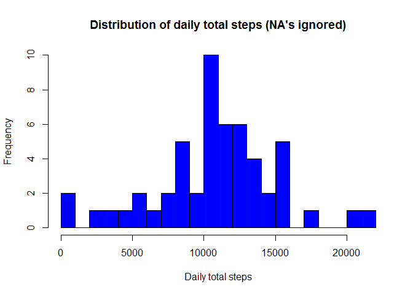

```r
hist(x=totStepsXDay$steps,
     col="blue",
     breaks=30,
     xlab="Daily total steps",
     ylab="Frequency",
     main="Distribution of daily total steps (NA's ignored)")
```

- The **median** number of steps taken per day is **10765**
- *The* **mean** * total number of steps taken per day is* **10766.2**

## III. What is the average daily activity pattern?

1. To answer this question, we need to aggregate the *mean* (average) number of steps taken each **interval** from the **sample1** dataframe. The aggregated data frame is stored in **avgStepsXInt** for additional examination. We also capture Which 5-minute interval, on average, across all days in the **sample1**, contains the maximum number of steps.

```r
   avgStepsXInt <- sample1                   %>%
                   group_by(interval)        %>%
                   filter(!is.na(steps))     %>%
                   summarise(steps = mean(steps, na.rm=TRUE))

   maxStepInt   <- avgStepsXInt$interval[which(avgStepsXInt$steps == max(avgStepsXInt$steps))]
```

2. The graph below is a time series plot of the 5-minute intervals (x-axis) and the average number of steps taken, averaged across all days (y-axis)

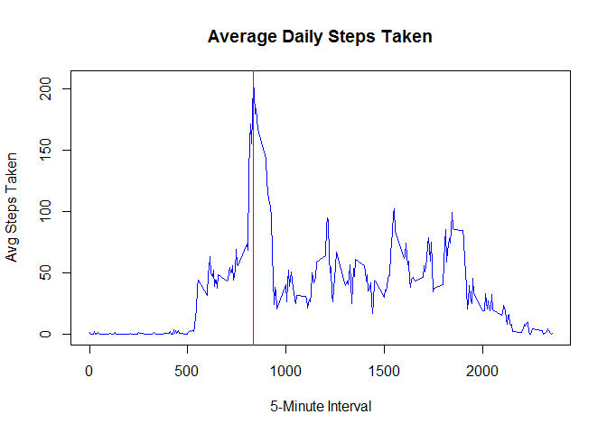

```r
   plot( avgStepsXInt$interval,
         avgStepsXInt$steps,
         type="l",
         main="Average Daily Steps Taken",
         xlab="5-Minute Interval",
         ylab="Avg Steps Taken",
         col="blue",
         lwd=1)

  abline(v=maxStepInt, col="red", lwd=0.5)
```

- The 5-minute interval,that contains the maximum number of steps is **835**

## IV. Imputing missing values

```r
   sample2       <- sample1
   mvalues       <- is.na(sample2$steps)
   avg_interval  <- tapply( sample2$steps,
                            sample2$interval,
                            mean,
                            na.rm=TRUE,
                            simplify = TRUE )

   sample2$steps[mvalues] <- avg_interval[as.character(sample2$interval[mvalues])]

   mvalues <- nrow(sample2[is.na(sample2$steps),])
```

2. Using the same method (as in step **II. What is mean total number of steps taken per day** above) we will now aggregate the *sum* (total) number of steps taken each **date** from the **sample2** dataframe containing our imputed missing steps. We also capture the **mean** and **median** number of steps taken per day. Our aggregated result set will be stored in **totStepsXDay2**

```r
   totStepsXDay2  <- sample2               %>%
                    group_by(date)         %>%
                    filter(!is.na(steps))  %>%
                    summarise(steps = sum(steps, na.rm=TRUE))

   meanSteps2    <- as.character(round(mean(totStepsXDay2$steps,na.rm=T ),1))
   medianSteps2  <- as.character(round(median(totStepsXDay2$steps,na.rm=T ),1))
```

3. To view distribution and visualize the mean total number of steps taken per day, we are presenting **totStepsXDay2** in a histogram

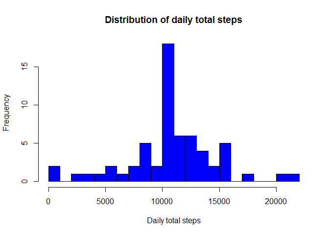

```r
hist(x=totStepsXDay2$steps,
     col="blue",
     breaks=30,
     xlab="Daily total steps",
     ylab="Frequency",
    main="Distribution of daily total steps")
```

- The **mean** number of steps taken per day is now **10766.2**
- The **median** number of steps taken per day is now **10766.2**

*The impact of imputing missing data with the average number of steps in the same 5-min interval is that* *both the* **mean** *and the* **median** *are same value :* **10766.2** *

## V. Are there differences in activity patterns between weekdays and weekends?

1. First we will add a variable called **type** to **sample2** by deriving the whether a particular date falls on a **weekday**, or **weekend**.

```r
   sample2  <- sample2  %>%
               mutate(type = ifelse(weekdays(sample2$date)=="Monday"    |
                                    weekdays(sample2$date)=="Tuesday"   |
                                    weekdays(sample2$date)=="Wednesday" |
                                    weekdays(sample2$date)=="Thursday"  |
                                    weekdays(sample2$date)=="Friday",
                                    "Weekday",
                                    "Weekend"))
```

```r
   avgStepsXIntXType <- sample2                   %>%
                        group_by(interval, type)  %>%
                        summarise(steps = mean(steps, na.rm=TRUE))


   str(avgStepsXIntXType)
```

```
## Classes 'grouped_df', 'tbl_df', 'tbl' and 'data.frame':  576 obs. of  3 variables:
##  $ interval: int  0 0 5 5 10 10 15 15 20 20 ...
##  $ type    : chr  "Weekday" "Weekend" "Weekday" "Weekend" ...
##  $ steps   : num  2.2512 0.2146 0.4453 0.0425 0.1732 ...
##  - attr(*, "vars")=List of 1
##   ..$ : symbol interval
##  - attr(*, "drop")= logi TRUE
```

3. Finally we make a panel plot containing a time series plot **(i.e. type = “l”)** of the 5-minute interval (x-axis) and the average number of steps taken, averaged across all weekday days or weekend days (y-axis).

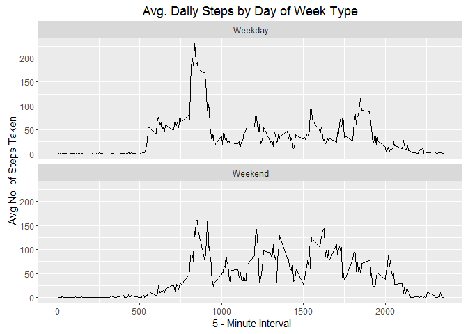

```r
    p <- ggplot( avgStepsXIntXType,
                 aes( x     = interval,
                      y     = steps))                                +
                 geom_line()                                         +
                 labs( title = "Avg. Daily Steps by Day of Week Type",
                       x     = " 5 - Minute Interval",
                       y     = "Avg No. of Steps Taken")             +
                  facet_wrap( ~type,
                              ncol = 1,
                              nrow = 2)
    print(p)
```

*The panel plot above illustrates there* **are** *differences in activity patterns between weekdays and weekends*